# LR_Attrition

```r
mod_24 <- glm(Attrition~.-BusinessTravel_Non_Travel -Department_Human_Resources -Education_5 -EducationField_Human_Resources
              -EnvironmentSatisfaction_1 -JobInvolvement_1 -JobRole_Human_Resources -JobSatisfaction_1
              -MaritalStatus_Divorced -PerformanceRating_4 -RelationshipSatisfaction_3
              -WorkLifeBalance_4 -JobRole_Sales_Executive -WorkLifeBalance_2 -Education_3
              -Education_2 -Department_Sales -JobRole_Laboratory_Technician -MaritalStatus_Married
              -RelationshipSatisfaction_4 -RelationshipSatisfaction_2 -PercentSalaryHike -StockOptionLevel
              -PerformanceRating_3 -MonthlyIncome  -HourlyRate -MonthlyRate -TotalWorkingYears -YearsAtCompany
              -Education_4 -Education_1 -Department_Research_Development -EducationField_Technical_Degree
              -YearsInCurrentRole -WorkLifeBalance_3 ,data = train, family = 'binomial')
summary(mod_24)
```

```
##
## Call:
## glm(formula = Attrition ~ . - BusinessTravel_Non_Travel - Department_Human_Resources -
##     Education_5 - EducationField_Human_Resources - EnvironmentSatisfaction_1 -
##     JobInvolvement_1 - JobRole_Human_Resources - JobSatisfaction_1 -
##     MaritalStatus_Divorced - PerformanceRating_4 - RelationshipSatisfaction_3 -
##     WorkLifeBalance_4 - JobRole_Sales_Executive - WorkLifeBalance_2 -
##     Education_3 - Education_2 - Department_Sales - JobRole_Laboratory_Technician -
##     MaritalStatus_Married - RelationshipSatisfaction_4 - RelationshipSatisfaction_2 -
##     PercentSalaryHike - StockOptionLevel - PerformanceRating_3 -
##     MonthlyIncome - HourlyRate - MonthlyRate - TotalWorkingYears -
##     YearsAtCompany - Education_4 - Education_1 - Department_Research_Development -
##     EducationField_Technical_Degree - YearsInCurrentRole - WorkLifeBalance_3,
##     family = "binomial", data = train)
##
## Deviance Residuals:
##     Min       1Q   Median       3Q      Max
## -3.6401   0.1012   0.2498   0.4545   1.9593
##
## Coefficients:
##                                   Estimate Std. Error z value Pr(>|z|)
## (Intercept)                        -0.1290     0.8129  -0.159 0.873924
## Age                                 2.0689     0.5699   3.630 0.000283 ***
## DailyRate                           0.3991     0.3506   1.138 0.254974
## DistanceFromHome                   -0.8952     0.3486  -2.568 0.010225 *
## Gender                             -0.3565     0.2130  -1.674 0.094186 .
## NumCompaniesWorked                 -1.5955     0.3669  -4.349 1.37e-05 ***
## OverTime                           -1.9793     0.2217  -8.929  < 2e-16 ***
## TrainingTimesLastYear               0.4736     0.4005   1.182 0.237072
## YearsSinceLastPromotion            -1.0175     0.4138  -2.459 0.013940 *
## YearsWithCurrManager                1.7490     0.6064   2.884 0.003923 **
## BusinessTravel_Travel_Rarely       -1.0943     0.4583  -2.387 0.016966 *
## BusinessTravel_Travel_Frequently   -1.9457     0.4973  -3.912 9.14e-05 ***
## EducationField_Life_Sciences        0.9666     0.3222   3.000 0.002703 **
## EducationField_Other                0.8340     0.5122   1.628 0.103465
## EducationField_Medical              1.0062     0.3321   3.030 0.002447 **
## EducationField_Marketing            0.5650     0.3833   1.474 0.140501
## EnvironmentSatisfaction_2           1.2837     0.3327   3.858 0.000114 ***
## EnvironmentSatisfaction_3           1.1320     0.2870   3.945 7.99e-05 ***
## EnvironmentSatisfaction_4           1.2261     0.2877   4.261 2.03e-05 ***
```

[output cut: 10 more lines]

```
## JobSatisfaction_2                   0.8831     0.3120   2.830 0.004648 **
## JobSatisfaction_3                   0.7532     0.2688   2.802 0.005073 **
## MaritalStatus_Single               -1.1768     0.2098  -5.610 2.03e-08 ***
## RelationshipSatisfaction_1         -0.8388     0.2432  -3.449 0.000563 ***
## WorkLifeBalance_1                  -1.3105     0.3695  -3.546 0.000390 ***
## ---
## Signif. codes:  0 '***' 0.001 '**' 0.01 '*' 0.05 '.' 0.1 ' ' 1
##
## (Dispersion parameter for binomial family taken to be 1)
##
##     Null deviance: 1006.61  on 1175  degrees of freedom
## Residual deviance:  663.55  on 1142  degrees of freedom
## AIC: 731.55
##
## Number of Fisher Scoring iterations: 7
```

```r
mod_fin <- glm(Attrition~.-BusinessTravel_Non_Travel -Department_Human_Resources -Education_5 -EducationField_Human_Resources
              -EnvironmentSatisfaction_1 -JobInvolvement_1 -JobRole_Human_Resources -JobSatisfaction_1
              -MaritalStatus_Divorced -PerformanceRating_4 -RelationshipSatisfaction_3
              -WorkLifeBalance_4 -JobRole_Sales_Executive -WorkLifeBalance_2 -Education_3
              -Education_2 -Department_Sales -JobRole_Laboratory_Technician -MaritalStatus_Married
              -RelationshipSatisfaction_4 -RelationshipSatisfaction_2 -PercentSalaryHike -StockOptionLevel
              -PerformanceRating_3 -MonthlyIncome  -HourlyRate -MonthlyRate -TotalWorkingYears -YearsAtCompany
              -Education_4 -Education_1 -Department_Research_Development -EducationField_Technical_Degree
              -YearsInCurrentRole -WorkLifeBalance_3 -DailyRate -TrainingTimesLastYear -EducationField_Marketing
              -EducationField_Other -JobRole_Research_Scientist -JobRole_Manager -JobRole_Manufacturing_Director,
              data = train, family = 'binomial')
summary(mod_fin)
```

```
##
## Call:
## glm(formula = Attrition ~ . - BusinessTravel_Non_Travel - Department_Human_Resources -
##     Education_5 - EducationField_Human_Resources - EnvironmentSatisfaction_1 -
##     JobInvolvement_1 - JobRole_Human_Resources - JobSatisfaction_1 -
##     MaritalStatus_Divorced - PerformanceRating_4 - RelationshipSatisfaction_3 -
##     WorkLifeBalance_4 - JobRole_Sales_Executive - WorkLifeBalance_2 -
##     Education_3 - Education_2 - Department_Sales - JobRole_Laboratory_Technician -
##     MaritalStatus_Married - RelationshipSatisfaction_4 - RelationshipSatisfaction_2 -
##     PercentSalaryHike - StockOptionLevel - PerformanceRating_3 -
##     MonthlyIncome - HourlyRate - MonthlyRate - TotalWorkingYears -
##     YearsAtCompany - Education_4 - Education_1 - Department_Research_Development -
##     EducationField_Technical_Degree - YearsInCurrentRole - WorkLifeBalance_3 -
##     DailyRate - TrainingTimesLastYear - EducationField_Marketing -
##     EducationField_Other - JobRole_Research_Scientist - JobRole_Manager -
##     JobRole_Manufacturing_Director, family = "binomial", data = train)
##
## Deviance Residuals:
##     Min       1Q   Median       3Q      Max
## -3.6449   0.1134   0.2581   0.4725   2.0017
##
## Coefficients:
##                                   Estimate Std. Error z value Pr(>|z|)
## (Intercept)                         0.6014     0.7121   0.845 0.398340
## Age                                 2.3331     0.5410   4.313 1.61e-05 ***
## DistanceFromHome                   -0.9179     0.3413  -2.689 0.007162 **
## Gender                             -0.3940     0.2092  -1.884 0.059576 .
## NumCompaniesWorked                 -1.6031     0.3595  -4.459 8.23e-06 ***
## OverTime                           -1.9401     0.2160  -8.980  < 2e-16 ***
## YearsSinceLastPromotion            -1.0289     0.4081  -2.521 0.011706 *
## YearsWithCurrManager                1.8428     0.5956   3.094 0.001973 **
## BusinessTravel_Travel_Rarely       -1.0339     0.4519  -2.288 0.022143 *
## BusinessTravel_Travel_Frequently   -1.8433     0.4883  -3.775 0.000160 ***
## EducationField_Life_Sciences        0.7136     0.2402   2.971 0.002969 **
## EducationField_Medical              0.7958     0.2563   3.104 0.001907 **
## EnvironmentSatisfaction_2           1.2881     0.3266   3.944 8.02e-05 ***
## EnvironmentSatisfaction_3           1.1587     0.2798   4.142 3.44e-05 ***
## EnvironmentSatisfaction_4           1.2905     0.2819   4.578 4.68e-06 ***
## JobInvolvement_3                    1.5218     0.4043   3.764 0.000167 ***
## JobInvolvement_2                    1.0079     0.4211   2.394 0.016688 *
## JobInvolvement_4                    1.7523     0.5425   3.230 0.001238 **
## JobRole_Healthcare_Representative   1.7605     0.6291   2.798 0.005136 **
## JobRole_Sales_Representative       -1.3648     0.3465  -3.939 8.18e-05 ***
## JobRole_Research_Director           2.2708     1.0582   2.146 0.031882 *
## JobSatisfaction_4                   1.5635     0.2870   5.447 5.11e-08 ***
## JobSatisfaction_2                   0.9448     0.3092   3.056 0.002244 **
## JobSatisfaction_3                   0.7844     0.2639   2.972 0.002958 **
## MaritalStatus_Single               -1.1673     0.2068  -5.645 1.65e-08 ***
## RelationshipSatisfaction_1         -0.8077     0.2392  -3.377 0.000733 ***
## WorkLifeBalance_1                  -1.3772     0.3607  -3.818 0.000135 ***
## ---
## Signif. codes:  0 '***' 0.001 '**' 0.01 '*' 0.05 '.' 0.1 ' ' 1
##
## (Dispersion parameter for binomial family taken to be 1)
##
##     Null deviance: 1006.61  on 1175  degrees of freedom
## Residual deviance:  676.38  on 1149  degrees of freedom
## AIC: 730.38
##
## Number of Fisher Scoring iterations: 7
```

Comments: Check the prediction on the train data.

```r
pred_train <- predict(mod_fin,train,type = 'response')
head(pred_train)
```

```
##      1210      1044      1418       116        79       843
## 0.9980130 0.9979853 0.8368218 0.9531525 0.9492987 0.9303012
```

Comments: Apply a threshold cut-off (Hit and Trial Method) and construct a Confusion Matrix for the same.

```r
pred_1 <- ifelse(pred_train > 0.5,1,0)
tab_1 <- table(Predicted = pred_1,Actual = train$Attrition)
tab_1
```

```
##          Actual
## Predicted   0   1
##         0  81  22
##         1  99 974
```

Comments: Calculate the accuracy on the Training dataset.

```r
pred_train_accuracy <- sum(diag(tab_1))/sum(tab_1)
pred_train_accuracy
```

```
## [1] 0.8971088
```

Comments: Check the prediction on the test data.

```r
pred_test <- predict(mod_fin,test,type = 'response')
head(pred_test)
```

```
##         2         4         6         7        13        14
## 0.9858741 0.7851408 0.9671416 0.8791198 0.8506570 0.9914925
```

Comments: Plot a cut-off vs accuracy graph to see the accuracy on various cut-offs.

```r
library(ROCR)
```

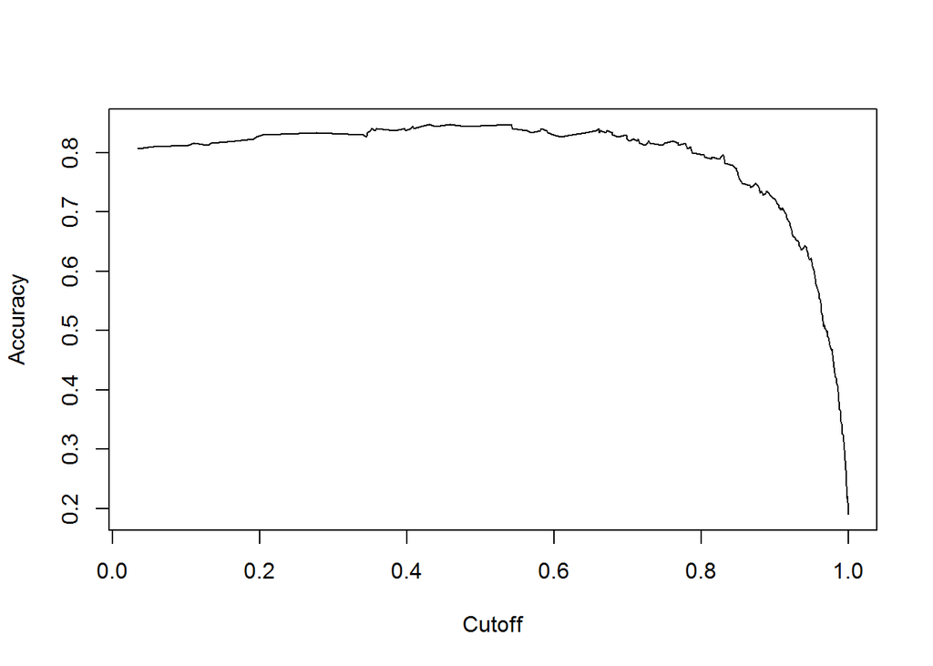

```r
pred <- prediction(pred_test,test$Attrition)
eval <- performance(pred,'acc')
plot(eval)
```

Comments: Find the maximum value of the accuracy, the algorithm can generate.

```r
max <- which.max(slot(eval,'y.values')[[1]])
acc <- slot(eval,'y.values')[[1]][max]
acc
```

```
## [1] 0.8469388
```

Comments: Find the maximum value of cut-off, for the maximum accuracy.

```r
cut_off <- slot(eval,'x.values')[[1]][max]
cut_off
```

```
##     311
## 0.54183
```

Comments: Using a value near to the above found cut-off, check the prediction for the test dataset.

```r
pred_2 <- ifelse(pred_test > 0.5,1,0)
tab_2 <- table(Predicted = pred_2, Actual = test$Attrition)
tab_2
```

```
##          Actual
## Predicted   0   1
##         0  21   9
##         1  36 228
```

```r
TP <- 21
TN <- 228
FP <- 9
FN <- 36
```

```r
Sensitivity <- TP/(TP+FN)
Sensitivity
```

```
## [1] 0.3684211
```

```r
Specificity <- TN/(FP+TN)
Specificity
```

```
## [1] 0.9620253
```

Comments: Compute the accuracy of the algorithm on the testing dataset.

```r
pred_test_accuracy <- sum(diag(tab_2))/sum(tab_2)
pred_test_accuracy
```

```
## [1] 0.8469388
```

Comments: Find the final p-value for the model to find out how significant the model stands (lesser the p-value, more significant the model).

```r
with(mod_fin, pchisq(null.deviance - deviance, df.null - df.residual, lower.tail = FALSE))
```

```
## [1] 1.803074e-54
```